# Assignment 5 - DESeq2

For more detailed instructions, please read the assignment page in the course textbook.

Use this block to source your `main.R`.

```r
source('main.R')
```

## 1. Reading and subsetting the data from verse_counts.tsv and sample_metadata.csv

To begin, we will subset the counts matrix to only contain a subset of samples found in the original data. We have provided you with the *full* counts matrix of samples and a metadata file containing relevant experimental variables for each sample. These files are named ‘verse_counts.tsv’ and ‘sample_metadata.csv’, respectively. Define a function that reads from these two files to construct a counts matrix and matching sample dataframe containing only samples belonging to the vP0 and vAd timepoints. This should correspond to a total of 4 samples (vP0_1, vP0_2, vAd_1, ’vAd_2). Store this counts matrix and the sample dataframe in a SummarizedExperiments object. Ensure that the name of your counts matrix stored as an assay in the SummarizedExperiment object is `counts`.

```
## class: SummarizedExperiment
## dim: 55416 4
## metadata(0):
## assays(1): counts
## rownames(55416): ENSMUSG00000102693.2 ENSMUSG00000064842.3 ...
##   ENSMUSG00000095019.2 ENSMUSG00000095041.8
## rowData names(0):
## colnames(4): vP0_1 vP0_2 vAd_1 vAd_2
## colData names(2): samplename timepoint
```

Display the colData from your SummarizedExperiment object here:

```
## DataFrame with 4 rows and 2 columns
##        samplename timepoint
##       <character>  <factor>
## vP0_1       vP0_1       vP0
## vP0_2       vP0_2       vP0
## vAd_1       vAd_1       vAd
## vAd_2       vAd_2       vAd
```

## 2. [Running DESeq2](http://bioconductor.org/packages/devel/bioc/vignettes/DESeq2/inst/doc/DESeq2.html#differential-expression-analysis)

DESeq2 has a built-in function that directly uses a SummarizedExperiment object. Define a function that takes your SummarizedExperiment and a design formula and runs DESeq2 with standard parameters. In our case, we wish to determine what genes are differentially expressed between our samples based on timepoint and our model will simply be `~ timepoint` and we will use `vP0` as our reference level.

Return a *list* containing both the results from DESeq2 as a dataframe as well as the DESeqDataSet object updated with various statistics in the course of the analysis (referred to as the dds in the vignette)

## 3. Annotating results to construct a labeled volcano plot

Using the results generated by DESeq2, convert it to a `tibble` and add one additional column that denotes whether a gene is either: 1. Upregulated and significant at a given padj threshold, 2.Downregulated and significant at a given padj threshold, or 3. Not significant at a given padj threshold. **Name this column `volc_plot_status`. Make sure the values for these labels are UP, DOWN, and NS, respectively.** Have your function take the DESeq2 results as well as a user-defined threshold for padj and set it at .10.

```
## # A tibble: 10 × 8
##    genes          volc_plot_status log2FoldChange      padj baseMean lfcSE  stat
##    <chr>          <chr>                     <dbl>     <dbl>    <dbl> <dbl> <dbl>
##  1 ENSMUSG000000… DOWN                      -9.86 1.26e-298   11732. 0.265 -37.2
##  2 ENSMUSG000000… UP                         6.18 1.11e-252    3547. 0.181  34.2
##  3 ENSMUSG000000… UP                         6.06 1.38e-201    2360. 0.198  30.6
##  4 ENSMUSG000000… DOWN                      -5.37 2.11e-196    3274. 0.178 -30.2
##  5 ENSMUSG000000… DOWN                      -6.77 1.52e-194   25698. 0.226 -30.0
##  6 ENSMUSG000000… UP                         5.30 1.81e-185    5568. 0.181  29.3
##  7 ENSMUSG000000… UP                         4.55 2.21e-167   24756. 0.163  27.9
##  8 ENSMUSG000000… DOWN                      -5.17 6.25e-164    2653. 0.187 -27.6
##  9 ENSMUSG000000… UP                         4.40 6.91e-159   11343. 0.162  27.1
## 10 ENSMUSG000000… DOWN                      -4.07 2.13e-150    6398. 0.154 -26.4
## # … with 1 more variable: pvalue <dbl>
```

### Captions for figures

```r
caption_4 <- 'Histogram of raw pvalues resulting from Differential Expression analysis'
caption_5 <- 'Histogram of Log2FoldChange values resulting from Differential Expression analysis'
caption_6 <- 'Plot of normalized counts for top ten Differential Expressed genes'
caption_7 <- 'Volcano plot of DESeq2 differential expression results (vP0 vs. vAd)'
caption_9 <- 'fgsea results for pathways with the top 10 most opsitive and negative NES scores'
```

## 4. Diagnostic plot of the raw p-values for all genes

Using the same results tibble from the previous function, plot a histogram of the raw p-values for all of the genes discovered in the experiment. Avoid using the base ggplot2 theme and make sure to label any appropriate axes and components of the plot.

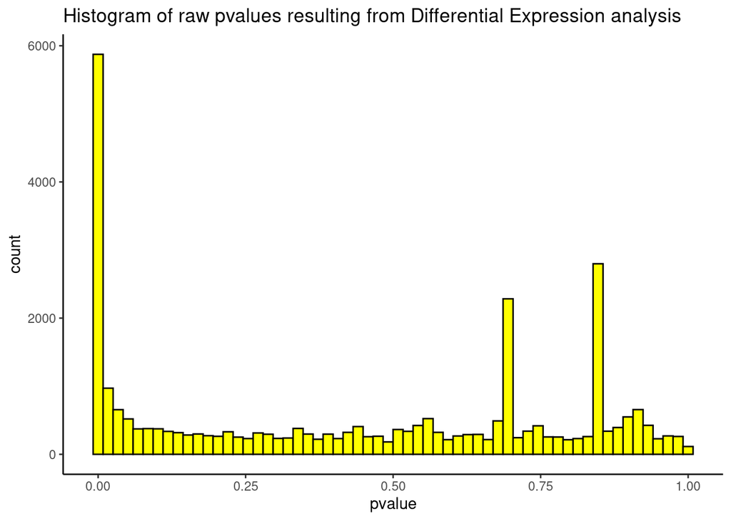

Histogram of raw pvalues resulting from Differential Expression analysis

## 5. Plotting the LogFoldChanges for differentially expressed genes

Using the results tibble, make a histogram of the Log2FoldChange values for all significant differentially expressed genes at a user-defined padj threshold and set this threshold to .10. Avoid using the base ggplot2 theme and make sure to label any appropriate axes and components of the plot.

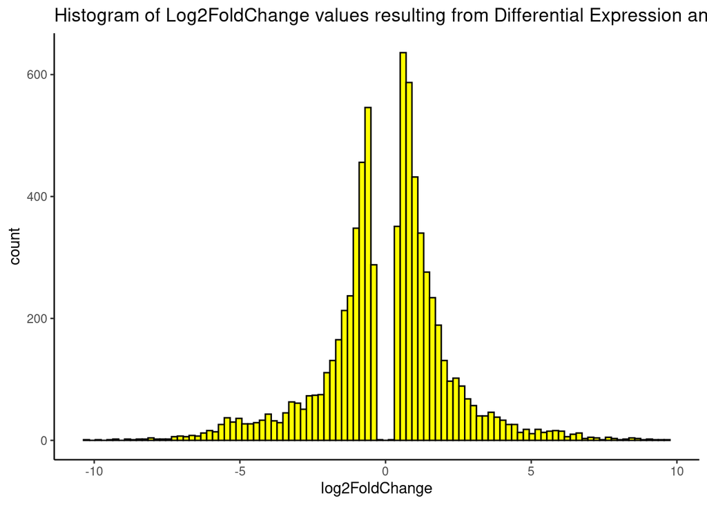

Histogram of Log2FoldChange values resulting from Differential Expression analysis

## 6. Plotting the normalized counts of differentially expressed genes

Extract out the DESeq2 normalized counts (by size factors) for the top ten differentially expressed genes as ranked by ascending padj. Make a scatter / jitter plot of the counts and label each by their samplenames.

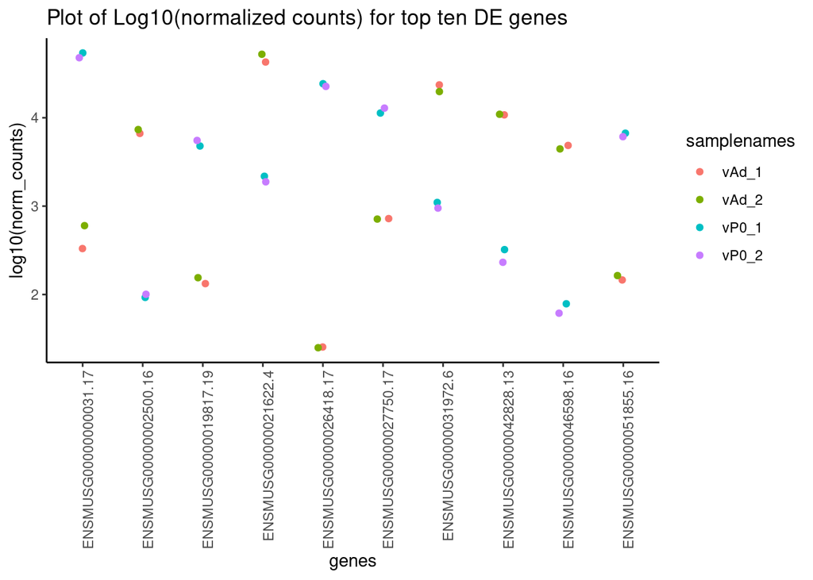

Plot of normalized counts for top ten Differential Expressed genes

## 7. Volcano Plot to visualize differential expression results

Using the status column you generated in part 3, make a volcano plot of the DESeq2 results and color the points appropriately.

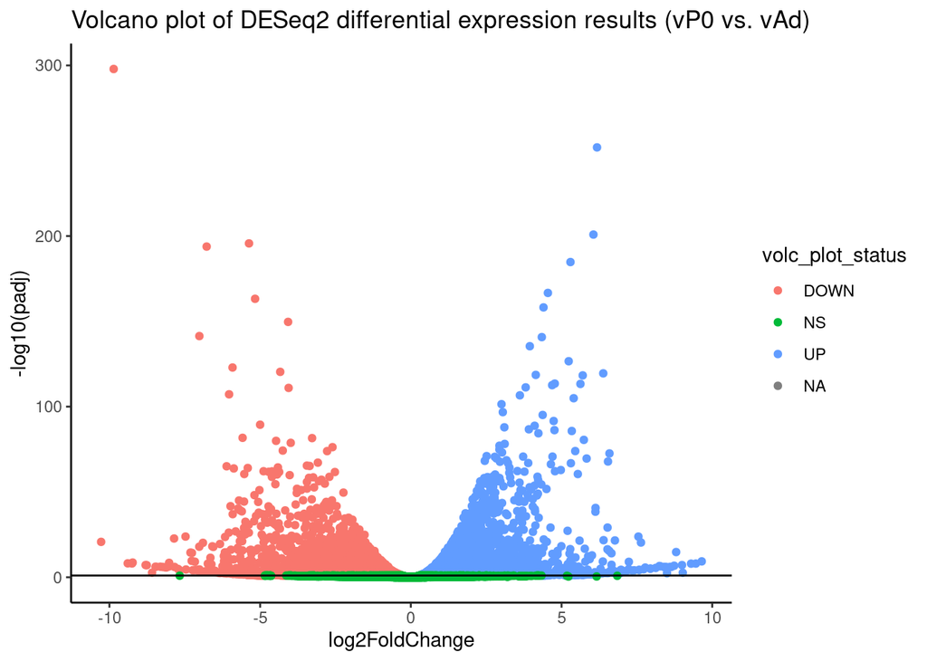

Volcano plot of DESeq2 differential expression results (vP0 vs. vAd)

## 8. Running fgsea

Perform a GSEA using a ranked list log2FoldChange values for all genes discovered in the DESeq2 results against the C2 Canonical Pathways gene set collection. Remember to convert the gene identifiers in our results to the appropriate matching format found in the C2 gene sets. fgsea expects a named vector of gene level statistics and the gene sets in the form of a named list. As recommended, please set the minSize and maxSize parameters to 15 and 500, respectively. Otherwise, run fgsea using default parameters and the `fgsea()` function.

```
## # A tibble: 1,981 × 8
##    pathway                  pval     padj log2err     ES   NES  size leadingEdge
##    <chr>                   <dbl>    <dbl>   <dbl>  <dbl> <dbl> <int> <list>
##  1 REACTOME_CELL_CYCLE… 5.48e-22 1.09e-18   1.21  -0.606 -2.50   269 <chr [71]>
##  2 REACTOME_MITOTIC_SP… 1.32e-18 1.31e-15   1.11  -0.723 -2.64   109 <chr [33]>
##  3 REACTOME_MITOTIC_PR… 1.03e-17 5.10e-15   1.09  -0.615 -2.44   195 <chr [63]>
##  4 REACTOME_RESOLUTION… 8.23e-18 5.10e-15   1.09  -0.695 -2.58   119 <chr [37]>
##  5 REACTOME_THE_CITRIC… 2.17e-16 8.61e-14   1.05   0.601  2.50   169 <chr [136]>
##  6 REACTOME_MITOTIC_ME… 7.88e-16 2.60e-13   1.03  -0.572 -2.31   225 <chr [42]>
##  7 WP_RETINOBLASTOMA_G… 3.18e-15 9.01e-13   1.01  -0.721 -2.55    85 <chr [50]>
##  8 PID_PLK1_PATHWAY     4.31e-14 1.07e-11   0.965 -0.825 -2.59    43 <chr [20]>
##  9 REACTOME_RESPIRATOR… 7.75e-14 1.71e-11   0.955  0.619  2.48   124 <chr [105]>
## 10 REACTOME_RHO_GTPASE… 1.93e-13 3.82e-11   0.944 -0.633 -2.39   132 <chr [34]>
## # … with 1,971 more rows
```

## 9. Plotting the top ten positive NES and top ten negative NES pathways

To make a quick visualization of these GSEA results, make a barchart for the pathways with the top ten most positive and top ten most negative NES scores. Color the bars by whether they have a positive or negative NES.

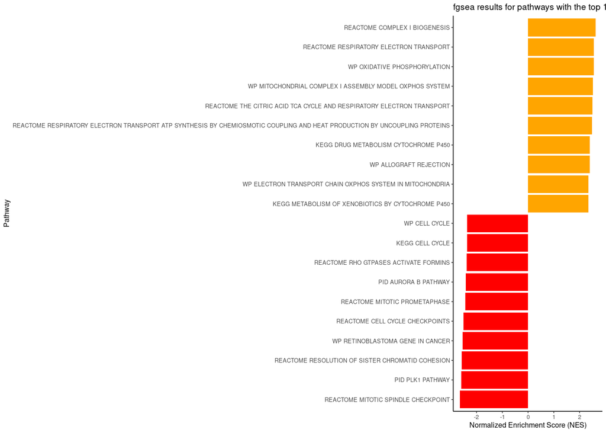

fgsea results for pathways with the top 10 most opsitive and negative NES scores